# pset7_results

## 1. Endogenous Grid Method (EGM) for non-stochastic NGM. (60 points)

Consider the optimization problem for a central planner, aiming to maximize

$$ \max_{\{c_t, k_{t+1}\}_{t=0}^\infty} \sum_{t=0}^\infty \beta^t u(c_t), \quad 0 < \beta < 1 $$

subject to:

$$ c_t + i_t = F(k_t, n_t), $$

$$ k_{t+1} = i_t + (1 - \delta) k_t, $$

$$ k_0 > 0 \ \text{given}. $$

The utility function and the production function are given by:

$$ u(c_t) = \frac{c_t^{1-\gamma}}{1-\gamma}, \quad F(k_t,1) = k_t^\alpha (1). $$

For this exercise use the following values for the parameters:

$$ \alpha = 0.36, \quad \beta = 0.98, \quad \delta = 0.03, \quad \gamma = 2. $$

### a) Solve the model using the EGM. Find both the value function and the policy functions for capital and consumption. (40)

**Answer.**  
You should write the code as we have explained in class, and obtain the following results:

*(Figure 1. Endogenous Grid Method Result)*

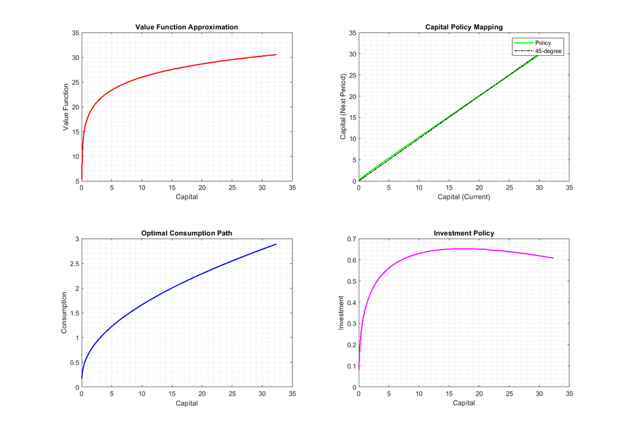

```matlab
close all; clear all; clc;

%% Part (a)
% Parameter setup
rho = 0.36;   % Capital share
disc = 0.98;  % Discount factor
dep = 0.03;   % Depreciation rate
riskAverse = 2;

% Steady-state capital computation
k_ss = ((rho * disc) / (1 - (1 - dep) * disc))^(1 / (1 - rho));

% Grid configuration
points = 500;
k_low = 0.001 * k_ss;
k_high = 1.5 * k_ss;
k_grid = linspace(k_low, k_high, points)';

% Wealth distribution
w_grid = k_grid.^rho + (1 - dep) * k_grid;

% Initialize storage for value function
v_func = zeros(points, 1);

% Compute initial values
for indx = 1:points
    v_func(indx) = util_fn(max(k_grid(indx)^rho, 1e-10), riskAverse);
end

% ****** Value Function Iteration ******
iter_max = 1000;
tolerance = 1e-10;
converged = false;

for step = 1:iter_max
    % Compute derivatives
    dV = zeros(points, 1);
    dV(1) = (v_func(2) - v_func(1)) / (w_grid(2) - w_grid(1));
    dV(end) = (v_func(end) - v_func(end-1)) / (w_grid(end) - w_grid(end-1));

    for indx = 2:points-1
        dV(indx) = (v_func(indx+1) - v_func(indx-1)) / (w_grid(indx+1) - w_grid(indx-1));
    end

    % Ensure positivity
    dV = max(dV, 1e-10);

    % Optimal consumption policy
    c_opt = max((disc * dV .* (rho * k_grid.^(rho-1) + 1 - dep)).^(-1 / riskAverse), 1e-10);

    % Implied wealth update
    w_new = c_opt + k_grid;

    % Value function update
    v_new = util_fn(c_opt, riskAverse) + disc * v_func;

    % Sorting to maintain monotonicity
    [w_new, indices] = sort(w_new);
    v_new = v_new(indices);

    % Remove duplicates
    [w_new, unique_indices] = unique(w_new);
    v_new = v_new(unique_indices);

    % Interpolation
    v_updated = interp1(w_new, v_new, w_grid, 'linear', 'extrap');

    % Convergence check
    if max(abs(v_updated - v_func)) < tolerance
        converged = true;
        break;
    end

    v_func = v_updated;
end

% ****** Policy Functions Computation ******
ks = zeros(points, 1);
for indx = 1:points
    objective = @(x) max(x^rho + (1 - dep) * x - w_new(indx), -1e10);
    ks(indx) = max(fsolve(objective, k_grid(indx), optimset('Display','off')), 1e-10);
end

% Ensure monotonicity
ks = max(ks, 1e-10);
[ks, sort_indices] = sort(ks);

% Interpolate onto regular grid
k_policy = interp1(ks, k_grid(sort_indices), k_grid, 'linear', 'extrap');
k_policy = max(k_policy, 1e-10);
c_policy = max(k_grid.^rho + (1 - dep) * k_grid - k_policy, 1e-10);
i_policy = k_policy - (1 - dep) * k_grid;

% ****** Graphing with Modified Style ******
figure('Position', [150, 150, 1300, 900]);

subplot(2,2,1);
plot(k_grid, v_func, 'r-', 'LineWidth', 1.8);
title('Value Function Approximation');
xlabel('Capital');
ylabel('Value Function');
grid minor;

subplot(2,2,2);
plot(k_grid, k_policy, 'g-', 'LineWidth', 1.8);
hold on;
plot(k_grid, k_grid, 'k-.', 'LineWidth', 1.2);
title('Capital Policy Mapping');
xlabel('Capital (Current)');
ylabel('Capital (Next Period)');
legend('Policy', '45-degree');
grid minor;

subplot(2,2,3);
plot(k_grid, c_policy, 'b-', 'LineWidth', 1.8);
title('Optimal Consumption Path');
xlabel('Capital');
ylabel('Consumption');
grid minor;

subplot(2,2,4);
plot(k_grid, i_policy, 'm-', 'LineWidth', 1.8);
title('Investment Policy');
xlabel('Capital');
ylabel('Investment');
grid minor;

% ****** Utility Function Definition ******
function utility = util_fn(consumption, gamma)
    consumption = max(consumption, 1e-10);
    if gamma == 1
        utility = log(consumption);
    else
        utility = (consumption.^(1 - gamma) - 1) / (1 - gamma);
    end
end
```

### b) Consider the case where:

$$ \alpha = 0.36, \quad \beta = 0.98, \quad \delta = 1, \quad \gamma = 1. $$

Solve the model using the EGM. Find both the value function and the policy functions for capital and consumption, and compare the solutions to the analytical solutions you can find in this case. (20)

**Answer.**  
Let us derive again the closed form solution that we have in this case.

$$ k_{t+1} = i_t = k_t^\alpha - c_t. $$

Suppose our value function is taken as the form:

$$ V(k_t) = A + B \ln(k_t). $$

Therefore, we shall have:

$$ \frac{\beta B}{k_{t+1}} = \frac{1}{c_t}, \quad \frac{1}{k_t} = \frac{\beta \alpha k_t^{\alpha - 1}}{k_{t+1}}. $$

This will suffice to show that:

$$ k_{t+1} = \alpha \beta k_t^\alpha. $$

Therefore, we have:

$$ \alpha \beta + \frac{\alpha}{B} = 1 $$

and we shall solve that:

$$ B = \frac{\alpha}{1 - \alpha \beta}. $$

Plug

$$ c_t = \frac{\alpha}{B} k_t^\alpha \quad \text{and} \quad k_{t+1} = \alpha \beta k_t^\alpha $$

into the Bellman equation; we shall have:

$$ A + B \ln(k_t) = \ln \left(\frac{\alpha}{B} k_t^\alpha \right) + \beta A + \beta B \ln\left(\alpha \beta k_t^\alpha\right). $$

Then, we shall have:

$$ A = \frac{\ln\left(\frac{\alpha}{B}\right) + \beta B \ln(\alpha \beta)}{1 - \beta}. $$

Thus:

$$ B = \frac{\alpha}{1 - \alpha \beta}. $$

Now, you should use the same code as in incise a) to obtain a numerical approximation. The results are shown below.

*(Figure 2. Endogenous Grid Method Result)*

Note that we also have the analytical solution by the procedure stated in the previous page. We can compare the result:

And we can observe from the figure that the analytical solution and numerical solution agree with each other.

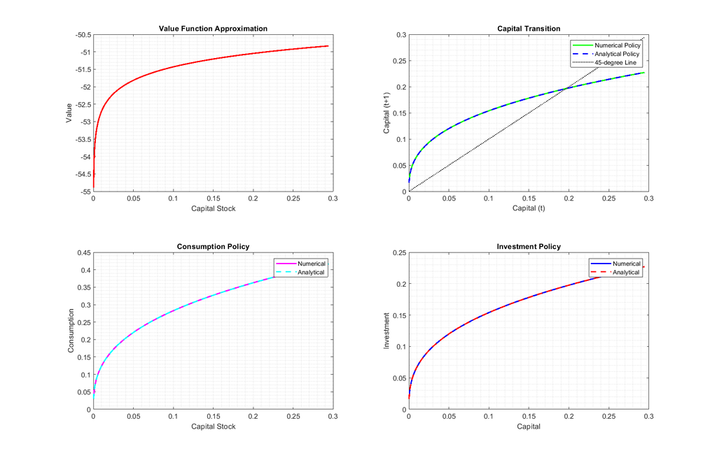

```matlab
%% -------- Part (b) ----------
close all; clear all;clc;

capital_share = 0.36;
discount_factor = 0.98;
depreciation = 1;
sigma = 1;  % Equivalent to gamma in GAUSS

% Compute steady-state capital
steady_k = ((capital_share * discount_factor) / (1 - (1 - depreciation) * discount_factor))^(1 / (1 - capital_share));

% ==== Discretization of State Space ====
grid_size = 500;
k_low = 0.001 * steady_k;
k_high = 1.5 * steady_k;
capital_grid = linspace(k_low, k_high, grid_size)';

% Wealth grid construction (GAUSS style)
wealth_grid = capital_grid.^capital_share + (1 - depreciation) * capital_grid;

% ==== Initialize Value Function ====
value_fn = zeros(grid_size, 1);
for idx = 1:grid_size
    value_fn(idx) = util_fn(capital_grid(idx)^capital_share, sigma);
end

% ==== Value Function Iteration ====
max_iterations = 1000;
threshold = 1e-10;
converged = false;

for iteration = 1:max_iterations
    % Compute derivatives (mimicking GAUSS dval)
    d_val = zeros(grid_size, 1);
    d_val(1) = (value_fn(2) - value_fn(1)) / (wealth_grid(2) - wealth_grid(1));
    d_val(end) = (value_fn(end) - value_fn(end-1)) / (wealth_grid(end) - wealth_grid(end-1));

    for idx = 2:grid_size-1
        d_val(idx) = (value_fn(idx+1) - value_fn(idx-1)) / (wealth_grid(idx+1) - wealth_grid(idx-1));
    end

    % Optimal consumption decision (GAUSS style)
    consumption_opt = (discount_factor * d_val .* (capital_share * capital_grid.^(capital_share-1) + 1 - depreciation)).^(-1 / sigma);

    % Compute updated wealth
    wealth_new = consumption_opt + capital_grid;

    % Update value function
    value_updated = util_fn(consumption_opt, sigma) + discount_factor * value_fn;

    % Interpolation to original grid
    value_fn_new = interp1(wealth_new, value_updated, wealth_grid, 'linear', 'extrap');

    % Check for convergence
    diff = max(abs(value_fn_new - value_fn));
    if diff < threshold
        converged = true;
        break;
    end
    value_fn = value_fn_new;
end

% ==== Compute Endogenous Capital Policy ====
endogenous_k = zeros(grid_size, 1);
for idx = 1:grid_size
    eqn_fn = @(x) x^capital_share + (1 - depreciation) * x - wealth_new(idx);
    endogenous_k(idx) = fsolve(eqn_fn, capital_grid(idx), optimset('Display', 'off'));
end

% ==== Policy Function Computation ====
k_policy = interp1(endogenous_k, capital_grid, capital_grid, 'linear', 'extrap');
consumption_policy = capital_grid.^capital_share + (1 - depreciation) * capital_grid - k_policy;
investment_policy = k_policy - (1 - depreciation) * capital_grid;

% ==== Analytical Solutions (σ=1, δ=1 Case) ====
k_policy_analytical = capital_share * discount_factor * capital_grid.^capital_share;
c_policy_analytical = capital_grid.^capital_share - k_policy_analytical;
i_policy_analytical = k_policy_analytical;

% ==== Graphical Representation (Modified Style) ====
figure('Position', [150, 150, 1400, 900]);

subplot(2,2,1);
plot(capital_grid, value_fn, 'r-', 'LineWidth', 2);
title('Value Function Approximation');
xlabel('Capital Stock');
ylabel('Value');
grid minor;

subplot(2,2,2);
plot(capital_grid, k_policy, 'g-', 'LineWidth', 2);
hold on;
plot(capital_grid, k_policy_analytical, 'b--', 'LineWidth', 2);
plot(capital_grid, capital_grid, 'k:', 'LineWidth', 1.2);
title('Capital Transition');
xlabel('Capital (t)');
ylabel('Capital (t+1)');
legend('Numerical Policy', 'Analytical Policy', '45-degree Line');
grid minor;

subplot(2,2,3);
plot(capital_grid, consumption_policy, 'm-', 'LineWidth', 2);
hold on;
plot(capital_grid, c_policy_analytical, 'c--', 'LineWidth', 2);
title('Consumption Policy');
xlabel('Capital Stock');
ylabel('Consumption');
legend('Numerical', 'Analytical');
grid minor;

subplot(2,2,4);
plot(capital_grid, investment_policy, 'b-', 'LineWidth', 2);
hold on;
plot(capital_grid, i_policy_analytical, 'r--', 'LineWidth', 2);
title('Investment Policy');
xlabel('Capital');
ylabel('Investment');
legend('Numerical', 'Analytical');
grid minor;
```

## 2. The stochastic Neoclassical Growth Model with variable labor supply. (120 points)

Consider again the non-stochastic NGM where the Central planner uses a Bellman equation to state the problem as:

$$ V(k) = \max_{c,k',\ell'} \bigl[u(c, \ell) + \beta V(k')\bigr] $$

subject to:

$$ k' + c = F(k, \ell) + (1 - \delta) k. $$

Throughout the problem use the following functional forms:

$$ u(c, \ell) = \frac{\bigl[c^\gamma (1 - \ell)^{1-\gamma}\bigr]^{1-\sigma}}{1 - \sigma}, \quad F(k, \ell) = k^\alpha \ell^{1-\alpha}. $$

### a) Assume for this incise that $\sigma = \delta = 1$. Use a Guess and Verify method for the value function to find the policy function for consumption, next period capital, and labor. (30)

**Answer.**  
We again use the guess

$$ V(k) = A + B \ln(k). $$

Then the Bellman equation can be written:

$$ V(k) = \gamma \ln\bigl(k^\alpha \ell^{1-\alpha}\bigr) + (1 - \gamma)\ln(1 - \ell) + \beta A + \beta B \ln(k'). $$

The FOC w.r.t. $k'$ and $\ell$ are given by:

$$ \frac{\gamma}{c} = \beta \frac{B}{k'}, $$

$$ \frac{\gamma}{c}(1 - \alpha) k^\alpha \ell^{-\alpha} = \frac{1 - \gamma}{1 - \ell}. $$

The resource constraint and the FOC w.r.t. $k'$ can be solved for consumption and next-period capital as:

$$ c = \frac{\gamma}{\gamma + \beta B} \, k^\alpha \ell^{1-\alpha}, \quad k' = \frac{\beta B}{\gamma} \, c. $$

We can then use the FOC w.r.t. $\ell$ to get:

$$ \ell = \frac{(\gamma + \beta B)(1 - \alpha)} {\gamma(1 - \gamma) + (\gamma + \beta B)(1 - \alpha)}. $$

Note that in this case labor is constant, independent of the stock of capital. Under $\sigma = 1 = \delta$, income and substitution effects cancel exactly, so labor becomes constant.

To find $B$, we equate coefficients in the Bellman equation (the usual procedure, details omitted here) and obtain:

$$ B = \frac{\gamma \alpha}{1 - \alpha \beta}. $$

Replacing this value in the policy functions for capital and consumption, we get:

$$ k' = \alpha \beta \, k^\alpha \ell^{1-\alpha}, \quad c = \bigl(1 - \alpha \beta\bigr) k^\alpha \ell^{1-\alpha}. $$

The solutions for the constant value of $\ell$ can be found by replacing $B$ in the expression above.

### b) Consider the policy functions for capital and labor:

$$ k' = g(k), \quad \ell = h(k). $$

Write down explicitly the operator $N(g, h) = 0$. (30)

**Answer.**  
Let me use the notation

$$ f(k, \ell) = k^\alpha \ell^{1-\alpha} + (1 - \delta) k. $$

Finding the optimality conditions of the problem, we have:

$$ u_c(c, \ell) = \beta f_k(k', \ell') \, u_c(c', \ell'), $$

$$ -\,u_\ell(c, \ell) = u_c(c, \ell) \, f_\ell(k, \ell), $$

along with the resource constraint $k' + c = f(k, \ell)$.

Consider now the policy functions $k' = g(k)$ and $\ell = h(k)$, and the following relationships:

$$ c = f(k, h(k)) - g(k), $$

$$ \ell' = h\bigl(g(k)\bigr), $$

$$ c' = f\bigl(g(k), h(g(k))\bigr) - g\bigl(g(k)\bigr). $$

Using this formulation, the operator $N$ is composed of two functionals:

$$ N_1\bigl(g(k), h(k)\bigr) = u_c\bigl(f(k, h(k)) - g(k),\, h(k)\bigr) \;-\; \beta\, f_k\bigl(g(k),\, h(g(k))\bigr)\, u_c\Bigl(f\bigl(g(k),\, h(g(k))\bigr) - g\bigl(g(k)\bigr),\, h\bigl(g(k)\bigr)\Bigr), $$

$$ N_2\bigl(g(k), h(k)\bigr) = -\,u_\ell\bigl(f(k, h(k)) - g(k),\, h(k)\bigr) \;-\; u_c\bigl(f(k, h(k)) - g(k),\, h(k)\bigr)\, f_\ell\bigl(k, h(k)\bigr). $$

### c) From now on, consider the following parametrization:

$$ \alpha = 0.36, \quad \delta = 0.03, \quad \beta = 0.98, \quad \sigma = 2. $$

Because we don’t have a value for $\gamma$, set $\ell = \frac{1}{3}$ (the steady-state value of labor). Use the optimality conditions of the problem to find the values in steady state of capital and consumption $\bigl(\bar{k}, \bar{c}\bigr)$ and the calibrated value for $\gamma$. (10)

**Answer.**  
The optimality conditions in steady state deliver:

$$ \ell = \frac{1}{3}, $$

$$ \bar{c} = 3 \left(\frac{1}{\beta} + \delta - 1\right)^{\frac{\alpha}{\alpha - 1}} - \delta \, \left[\frac{1}{3}\left(\frac{1}{\beta} + \delta - 1\right)\right]^{\frac{1}{\alpha - 1}}, $$

with the closed-form solution for $\gamma$ as:

$$ \gamma = \frac{1} {\displaystyle \left((1-\alpha)\left(\frac{\bar{k}}{\ell}\right)^\alpha \,\frac{1-\ell}{\bar{c}}\right) + 1}. $$

### d) Use an approximation for the policy functions for capital $k'$ and labor $\ell$ as follows:

$$ k' \equiv \hat{g}\bigl(k; a\bigr) = \sum_{i=1}^{n} a_i \,\varphi_i(k), \quad \ell \equiv \hat{h}\bigl(k;b\bigr) = \sum_{i=1}^{n} b_i \,\psi_i(k), $$

where

$$ \varphi_i(k) = k \, T_{i-1}(k) \,.\!= k \cos\bigl((i-1)\arccos(k)\bigr), \quad \psi_i(k) = T_{i-1}(k) \,.\!= \cos\bigl((i-1)\arccos(k)\bigr). $$

Use orthogonal collocation to find approximations to the policy functions for capital, labor, and consumption for a range $[0.3 \bar{k},\, 1.2 \bar{k}]$. Use $n = 8$. *(Hint: if it helps, you can start with a good guess for the case $\sigma = 1 = \delta$.)* (50)

**Answer.**  
Coding the orthogonal collocation method as we have explained in class, you should obtain the following:

#### Policy function for capital

```
                                             Norm of      First-order   Trust-region
 Iteration  Func-count     ||f(x)||^2           step       optimality         radius
     0         17             0.14017                            6.55              1
     1         18             0.14017       0.224575             6.55              1
     2         35           0.0535063      0.0561437             8.32         0.0561
     3         52         3.93216e-05      0.0057278            0.186         0.0561
     4         69         4.85812e-10    0.000334931         0.000585         0.0561
     5         86         8.21637e-19    3.86068e-06         2.46e-08         0.0561
     6        103         1.13559e-28    5.92452e-10          1.3e-13         0.0561

Equation solved.

fsolve completed because the vector of function values is near zero
as measured by the value of the function tolerance, and
the problem appears regular as measured by the gradient.
```

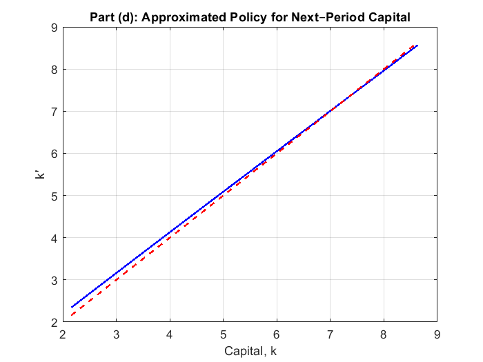

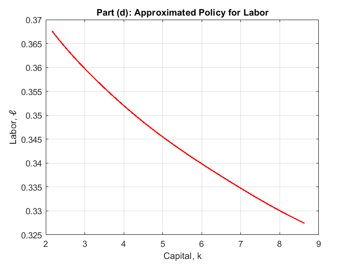

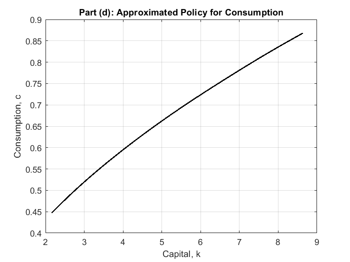

```matlab
%% ---------------------- Part (d): Orthogonal Collocation ----------------------
clear all; close all; clc;

% Approximate the policy functions for next–period capital and labor:
%
%   k' ≡ ĝ(k; a) = Σ_{i=1}^{n} a_i φ_i(k)
%   ℓ ≡ ĥ(k; b) = Σ_{i=1}^{n} b_i ψ_i(k)
%
% with basis functions:
%
%   φ_i(k) = k·T_{i-1}(x),   ψ_i(k) = T_{i-1}(x),
%
% where T_{i-1}(x) are Chebyshev polynomials, and
% x = (2*k - (k_min+k_max))/(k_max-k_min) transforms k into [-1, 1].
%
% We solve for the coefficient vectors a and b such that the Euler
% and intratemporal conditions (expressed via the residual operator) vanish.

% ---------------------- Parameters ----------------------
alpha     = 0.36;
delta     = 0.03;
beta      = 0.98;
sigma     = 2;
lbar      = 1/3;
gamma_cal = 0.48;

% Compute steady-state capital from the Euler condition:
kbar = fzero(@(k) beta*(alpha*k^(alpha-1)*lbar^(1-alpha)+1-delta)-1, 10);
cbar = kbar^alpha * lbar^(1-alpha) - delta*kbar;

% Collocation Domain ----------------------
n       = 8;           % number of basis functions
k_min   = 0.3 * kbar;  % lower bound for collocation domain
k_max   = 1.2 * kbar;  % upper bound for collocation domain
j       = (1:n)';
x_nodes = cos((2*j-1)*pi/(2*n));         % Chebyshev nodes in [-1,1]
k_nodes = ((k_max - k_min)/2)*x_nodes + (k_max+k_min)/2;  % transform to k-space

% Basis Functions ----------------------
% Chebyshev polynomial basis functions.
T   = @(i,x) cos((i-1).*acos(x));  % T_{i-1}(x)
phi = @(i,k) k .* T(i, (2*k - (k_min+k_max))/(k_max-k_min));
psi = @(i,k) T(i, (2*k - (k_min+k_max))/(k_max-k_min));

% ---------------------- Initial Guess ----------------------
% A good initial guess is to set a1 ≈ 1 (so that g(k) ≈ k) and b1 ≈ lbar.
X0 = [1; zeros(n-1,1); lbar; zeros(n-1,1)];  % X = [a; b]

% ---------------------- Solve Collocation System ----------------------
options = optimoptions('fsolve','Display','iter','TolFun',1e-8);
[X_sol, ~, ~, ~] = fsolve(@(X) collocation_resid(X, k_nodes, alpha, beta, delta, sigma, gamma_cal, k_min, k_max), X0, options);

% Extract coefficients
a = X_sol(1:n);
b = X_sol(n+1:2*n);

% ---------------------- Evaluate Approximated Policy Functions ----------------------
Nfine = 100;
k_fine = linspace(k_min, k_max, Nfine)';
g_k  = zeros(size(k_fine));
h_k  = zeros(size(k_fine));
for i = 1:Nfine
    k_val = k_fine(i);
    temp_phi = zeros(n,1);
    temp_psi = zeros(n,1);
    for j = 1:n
        temp_phi(j) = phi(j, k_val);
        temp_psi(j) = psi(j, k_val);
    end
    g_k(i) = a' * temp_phi;
    h_k(i) = b' * temp_psi;
end
% Consumption policy: c = k^α ℓ^(1-α) + (1-δ)*k - g(k)
c_policy = k_fine.^alpha .* h_k.^(1-alpha) + (1-delta)*k_fine - g_k;

% ---------------------- Plot Policy Functions ----------------------
figure;
plot(k_fine, g_k, 'b','LineWidth',1.5);
hold on
plot(k_fine, k_fine, 'r--','LineWidth',1.5);  % Add the 45° line
title('Part (d): Approximated Policy for Next–Period Capital');
xlabel('Capital, k'); ylabel('k'''); grid on;

figure;
plot(k_fine, h_k, 'r','LineWidth',1.5);
title('Part (d): Approximated Policy for Labor');
xlabel('Capital, k'); ylabel('Labor, ℓ'); grid on;

figure;
plot(k_fine, c_policy, 'k','LineWidth',1.5);
title('Part (d): Approximated Policy for Consumption');
xlabel('Capital, k'); ylabel('Consumption, c'); grid on;


% ---------------------- Collocation Residual Function ----------------------
function F = collocation_resid(X, k_nodes, alpha, beta, delta, sigma, gamma_cal, k_min, k_max)
% X is a vector of length 2*n: the first n entries are the coefficients a for
% the capital policy, and the next n entries are the coefficients b for the labor policy.
n = length(X) / 2;
a = X(1:n);
b = X(n+1:2*n);

F = zeros(2*n, 1);

% Define basis functions in this function as well, using the provided k_min and k_max.
T   = @(i,x) cos((i-1).*acos(x));
phi = @(i,k) k .* T(i, (2*k - (k_min+k_max))/(k_max-k_min));
psi = @(i,k) T(i, (2*k - (k_min+k_max))/(k_max-k_min));

for j = 1:n
    k = k_nodes(j);
    % Compute the basis functions at the current state k.
    temp_phi = zeros(n,1);
    temp_psi = zeros(n,1);
    for i = 1:n
        temp_phi(i) = phi(i, k);
        temp_psi(i) = psi(i, k);
    end
    kprime = a' * temp_phi;   % g(k)
    ell    = b' * temp_psi;    % h(k)

    % Current consumption: c = k^α * ell^(1-α) + (1-δ)*k - g(k)
    c = k^alpha * ell^(1-alpha) + (1-delta)*k - kprime;

    % Evaluate future policies at kprime.
    temp_phi_future = zeros(n,1);
    temp_psi_future = zeros(n,1);
    for i = 1:n
        temp_phi_future(i) = phi(i, kprime);
        temp_psi_future(i) = psi(i, kprime);
    end
    kprime_future = a' * temp_phi_future;   % g(k')
    ell_future    = b' * temp_psi_future;     % h(k')

    % Future consumption: c' = (kprime)^α * (ell_future)^(1-α) + (1-δ)*kprime - g(k')
    c_future = kprime^alpha * ell_future^(1-alpha) + (1-delta)*kprime - kprime_future;

    % Compute marginal utilities for current consumption:
    % u(c,ℓ) = [ c^(gamma_cal) (1-ℓ)^(1-gamma_cal) ]^(1-sigma) / (1-sigma)
    % Thus, u_c = [c^(gamma_cal)*(1-ℓ)^(1-gamma_cal)]^(-sigma)*gamma_cal*c^(gamma_cal-1)*(1-ℓ)^(1-gamma_cal)
    %      u_ell = -[c^(gamma_cal)*(1-ℓ)^(1-gamma_cal)]^(-sigma)*(1-gamma_cal)*c^(gamma_cal)*(1-ℓ)^(-gamma_cal-1)
    uc = (c^(gamma_cal) * (1-ell)^(1-gamma_cal))^(-sigma) * gamma_cal * c^(gamma_cal-1) * (1-ell)^(1-gamma_cal);
    ul = - (c^(gamma_cal) * (1-ell)^(1-gamma_cal))^(-sigma) * (1-gamma_cal) * c^(gamma_cal) * (1-ell)^(-gamma_cal-1);

    % Marginal utility for future consumption:
    uc_future = (c_future^(gamma_cal) * (1-ell_future)^(1-gamma_cal))^(-sigma) * gamma_cal * c_future^(gamma_cal-1) * (1-ell_future)^(1-gamma_cal);

    % Euler equation residual:
    %   u_c(c,ell) - beta * u_c(c',ell')*[alpha * kprime^(alpha-1)*ell_future^(1-alpha) + 1-delta] = 0
    RE = uc - beta * uc_future * (alpha * kprime^(alpha-1) * ell_future^(1-alpha) + 1-delta);

    % Intratemporal (labor) residual:
    %   u_ell(c,ell) + u_c(c,ell)*(1-alpha)*k^alpha*ell^(-alpha) = 0
    RL = ul + uc*(1-alpha)*k^alpha*ell^(-alpha);

    F(j)   = RE;
    F(j+n) = RL;
end
end
```